# Q & K Box 13.4

Fill et al (2021) studied the effect of duff (leaf litter) on the post-fire ecology of wiregrass (*Aristida beyrichiana*) in a section of pine savanna. They sampled 99 plants in an area of 0.1 km<sup>2</sup>, recorded plant basal area and allocated each plant to one of three treatments: high duff, low duff, low duff with added pine cones. They then burnt the area and five months later, counted the number of culms on each plant. We will model numbers of culms per plant against basal area and duff treatment using each plant as the unit of analysis.

This box explores several different ways in which count data can be treated, from the “classical” OLS models where the counts are square-root transformed, to GLMs based on the poisson distribution, to several options for data that are overdispersed.

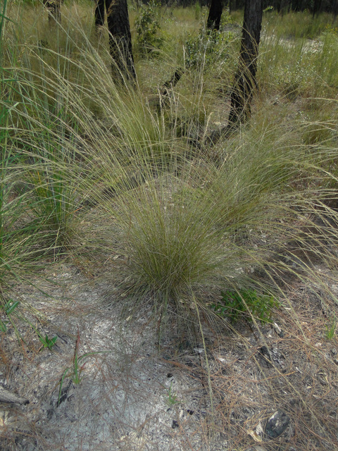

*Aristida beyrichiana*. [© Copyright Bobby Hattaway 2011/Discover Life](https://www.discoverlife.org/ap/copyright.html)

The paper is [here](https://doi.org/10.1371/journal.pone.0247159) and Figure 1 has relevant photos.

Fill, J. M., Zamora, C., Baruzzi, C., Salazar-Castro, J. & Crandall, R. M. (2021). Wiregrass (*Aristida beyrichiana*) survival and reproduction after fire in a long-unburned pine savanna. *PLoS One*, 16, e0247159.

### Preliminaries

First, load the required packages (car, performance, MuMIn, statmod, lmtest, vcd, Rmisc, MASS, pscl)

Import fill data file (fill.csv)

```r
fill <- read.csv("../data/fill.csv")
fill
```

| culm | reprod | basalarea | treatment |
| --- | --- | --- | --- |
| 8 | 1 | 11.83780 | High Duff |
| 19 | 1 | 160.92500 | High Duff |
| 3 | 1 | 15.93550 | High Duff |
| 9 | 1 | 84.78000 | High Duff |
| 44 | 1 | 346.97000 | High Duff |
| 15 | 1 | 82.15025 | High Duff |
| 4 | 1 | 43.52040 | High Duff |
| 0 | 0 | 8.24250 | High Duff |
| 1 | 1 | 41.01625 | High Duff |
| 1 | 1 | 229.69100 | High Duff |

[output cut: 89 more lines]

Check culm distribution with histogram

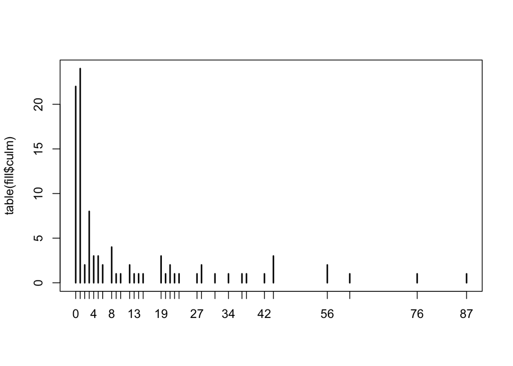

```r
plot(table(fill$culm))
```

Boxplot against treatment

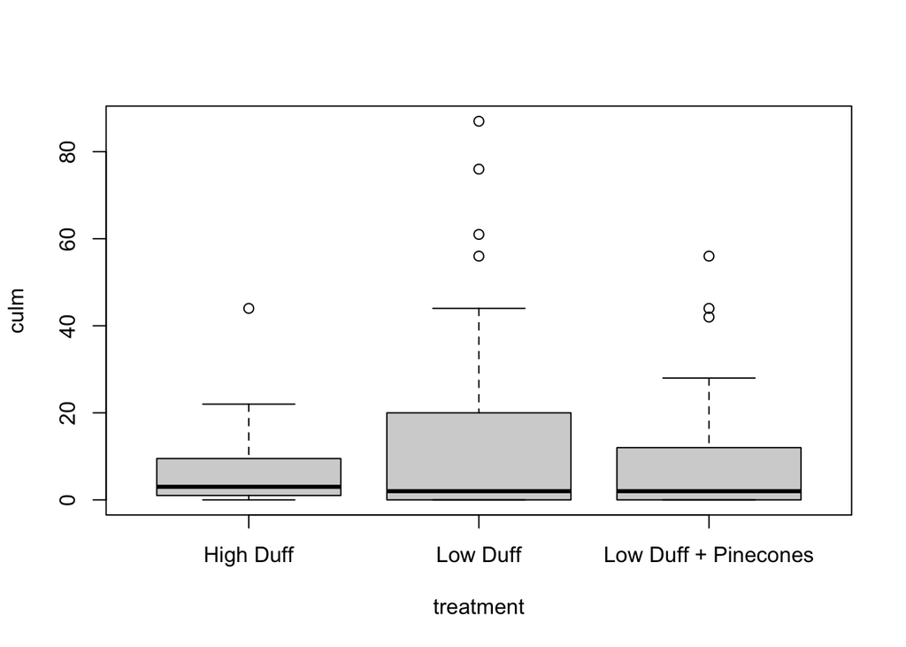

```r
boxplot(culm~treatment, data=fill)
```

Data possibly over-dispersed for poisson

```r
summarySE(data=fill, measurevar="culm", groupvars=c("treatment"))
```

| treatment | N | culm | sd | se | ci |
| --- | --- | --- | --- | --- | --- |
| High Duff | 28 | 7.464286 | 9.931179 | 1.876816 | 3.850909 |
| Low Duff | 46 | 13.739130 | 21.714752 | 3.201665 | 6.448485 |
| Low Duff + Pinecones | 25 | 10.560000 | 16.093684 | 3.218737 | 6.643146 |

## Fit poisson glm

```r
fill1.glm <- glm(culm~basalarea+treatment+basalarea*treatment, family=poisson, data=fill)
summary(fill1.glm)
```

```
##
## Call:
## glm(formula = culm ~ basalarea + treatment + basalarea * treatment,
##     family = poisson, data = fill)
##
## Coefficients:
##                                           Estimate Std. Error z value Pr(>|z|)
## (Intercept)                              2.0040614  0.0870699  23.017  < 2e-16
## basalarea                                0.0000407  0.0003528   0.115  0.90815
## treatmentLow Duff                        0.2112408  0.1010590   2.090  0.03659
## treatmentLow Duff + Pinecones           -0.4384083  0.1330034  -3.296  0.00098
## basalarea:treatmentLow Duff              0.0015309  0.0003625   4.223 2.41e-05
## basalarea:treatmentLow Duff + Pinecones  0.0038881  0.0004487   8.665  < 2e-16
##
## (Intercept)                             ***
## basalarea
## treatmentLow Duff                       *
## treatmentLow Duff + Pinecones           ***
## basalarea:treatmentLow Duff             ***
## basalarea:treatmentLow Duff + Pinecones ***
## ---
## Signif. codes:  0 '***' 0.001 '**' 0.01 '*' 0.05 '.' 0.1 ' ' 1
##
## (Dispersion parameter for poisson family taken to be 1)
##
##     Null deviance: 2101.6  on 98  degrees of freedom
## Residual deviance: 1599.9  on 93  degrees of freedom
## AIC: 1891.3
##
## Number of Fisher Scoring iterations: 6
```

```r
AICc(fill1.glm)
```

```
## [1] 1892.183
```

Check deviance residuals, influential values and collinearity

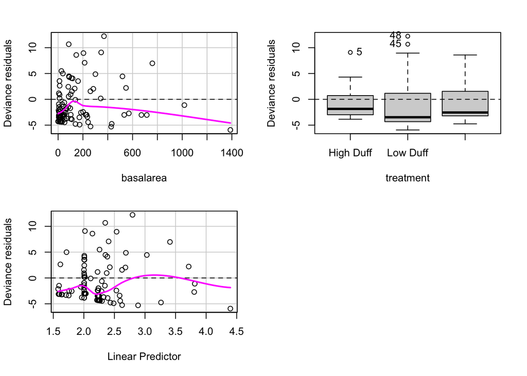

```
##           Test stat Pr(>|Test stat|)
## basalarea    247.27        < 2.2e-16 ***
## treatment
## ---
## Signif. codes:  0 '***' 0.001 '**' 0.01 '*' 0.05 '.' 0.1 ' ' 1
```

```r
residualPlots(fill1.glm, type="deviance")
```

```r
residuals(fill1.glm, type="deviance")
```

```
##           1           2           3           4           5           6
##  0.20923286  3.52437571 -1.84696896  0.55169766  9.08063242  2.43049570
##           7           8           9          10          11          12
## -1.38139530 -3.85269153 -2.97516095 -2.99178806 -2.98053360 -3.03476511
##          13          14          15          16          17          18
## -3.85618268 -3.03090905  4.05076046 -2.97604160 -2.99110558  4.30805157
##          19          20          21          22          23          24
## -2.36631486 -0.94501752  3.54431734  0.89789475 -2.97441165 -1.85136763
##          25          26          27          28          29          30
## -1.85196037 -0.94785624  0.17193562 -3.01860601  5.48494095  1.16145876
##          31          32          33          34          35          36
## -4.34220066 -5.25716243 -4.32602610 -3.49888536 -3.49517373 -4.29319540
##          37          38          39          40          41          42
## -2.41941660 -3.47184250 -4.38810960 -4.28248340 -4.77859577 -4.28182304
##          43          44          45          46          47          48
##  6.97214474 -4.90583052 10.66755976  4.45929577  4.44436791 12.21787559
##          49          50          51          52          53          54
##  8.94763007  4.86958756 -5.92962494 -3.40832404 -1.49205900 -4.36327765
##          55          56          57          58          59          60
## -1.12152934 -3.46773903 -4.46042903  1.56370632 -2.43527977 -4.42660331
##          61          62          63          64          65          66
## -3.87713567 -3.71109682  2.08390937  0.95140425 -1.98548186 -3.51762919
##          67          68          69          70          71          72
##  4.11500950 -1.98220634 -4.32655983 -3.71063761 -3.53833655 -5.30155193
##          73          74          75          76          77          78
## -0.63014935 -2.39743624  8.58300081 -3.39841806 -3.78053165 -0.09213929
##          79          80          81          82          83          84
##  1.54731185 -3.14245871  4.99032310 -3.21638933  2.20660594 -1.49845051
##          85          86          87          88          89          90
##  7.07694236 -2.71701487 -3.15255411 -4.74932844  2.02824210 -2.47070604
##          91          92          93          94          95          96
## -2.55251080  2.63055203 -3.32358182 -2.13220538 -2.56631805 -3.12496585
##          97          98          99
## -1.71855808 -3.20060647 -3.50413976
```

```r
influence.measures(fill1.glm)
```

```
## Influence measures of
##   glm(formula = culm ~ basalarea + treatment + basalarea * treatment,      family = poisson, data = fill) :
##
##       dfb.1_  dfb.bslr  dfb.trLD  dfb.tD.P  dfb.b.LD  dfb.bD.P    dffit cov.r
## 1   1.22e-02 -7.03e-03 -1.05e-02 -7.99e-03  6.84e-03  5.53e-03  0.01221 1.127
## 2   1.26e-01  9.34e-03 -1.09e-01 -8.28e-02 -9.09e-03 -7.34e-03  0.16663 1.054
## 3  -1.07e-01  6.02e-02  9.19e-02  6.98e-02 -5.86e-02 -4.74e-02 -0.10677 1.111
## 4   2.59e-02 -8.64e-03 -2.23e-02 -1.70e-02  8.41e-03  6.79e-03  0.02740 1.110
## 5   8.43e-02  4.61e-01 -7.27e-02 -5.52e-02 -4.48e-01 -3.62e-01  0.64985 0.816
## 6   1.15e-01 -3.97e-02 -9.93e-02 -7.55e-02  3.86e-02  3.12e-02  0.12144 1.086
## 7  -7.36e-02  3.56e-02  6.34e-02  4.82e-02 -3.46e-02 -2.80e-02 -0.07454 1.110
## 8  -2.28e-01  1.34e-01  1.97e-01  1.49e-01 -1.30e-01 -1.05e-01 -0.22817 1.063
## 9  -1.60e-01  7.86e-02  1.38e-01  1.05e-01 -7.65e-02 -6.18e-02 -0.16186 1.081
## 10 -7.78e-02 -5.78e-02  6.70e-02  5.09e-02  5.63e-02  4.55e-02 -0.15346 1.075
## 11 -1.33e-01  3.43e-02  1.14e-01  8.68e-02 -3.34e-02 -2.70e-02 -0.14477 1.071
```

[output cut: 188 more lines]

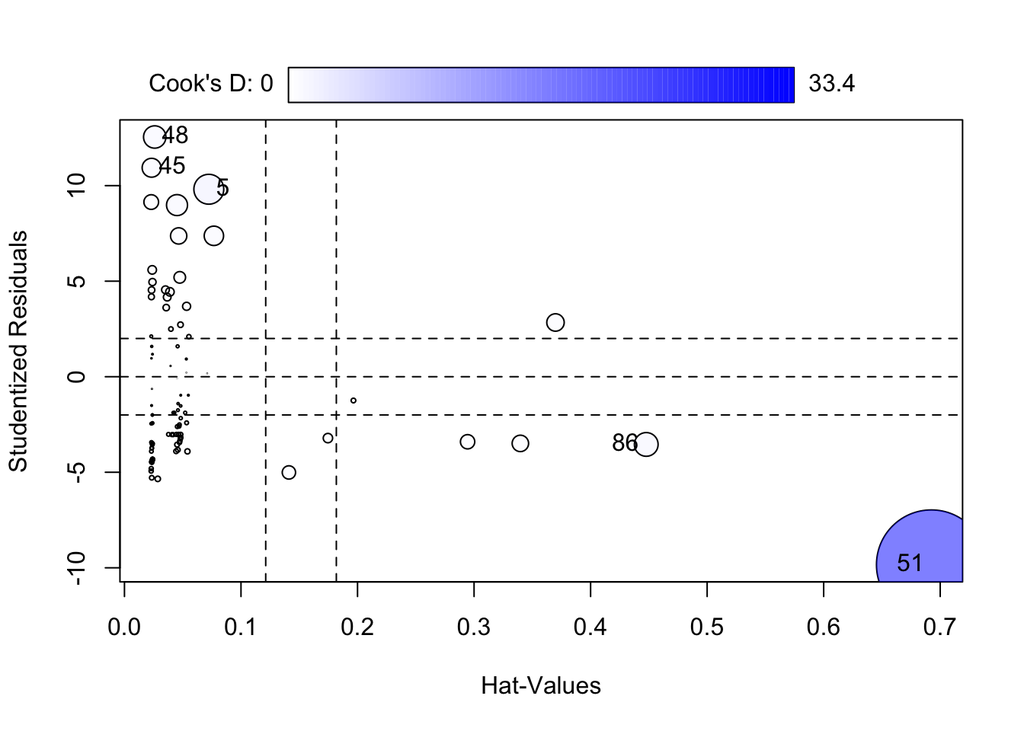

|  | StudRes | Hat | CookD |
| --- | --- | --- | --- |
| 5 | 9.810900 | 0.07237805 | 2.4787185 |
| 45 | 10.935984 | 0.02327481 | 0.9895175 |
| 48 | 12.545495 | 0.02596443 | 1.3882039 |
| 51 | -9.841300 | 0.69239565 | 33.4253663 |
| 86 | -3.543642 | 0.44774786 | 1.5618564 |

```r
influencePlot(fill1.glm)
```

```r
vif(lm(culm ~ basalarea+treatment+basalarea*treatment, data=fill))
```

```
## there are higher-order terms (interactions) in this model
## consider setting type = 'predictor'; see ?vif
```

```
##                         GVIF Df GVIF^(1/(2*Df))
## basalarea           4.832804  1        2.198364
## treatment           2.439885  2        1.249805
## basalarea:treatment 8.588810  2        1.711919
```

Check collinearity - OK

### Test interaction

```r
fill2.glm <- glm(culm~basalarea+treatment, family=poisson, data=fill)
lrtest(fill1.glm, fill2.glm)
```

|  | #Df | LogLik | Df | Chisq | Pr(>Chisq) |
| --- | --- | --- | --- | --- | --- |
| 1 | 6 | -939.6352 | NA | NA | NA |
| 2 | 4 | -984.5017 | -2 | 89.73303 | 3.27129e-20 |

Get analysis of deviance table

```r
anova(fill1.glm, test="LRT")
```

|  | Df | Deviance | Resid. Df | Resid. Dev | Pr(>Chi) |
| --- | --- | --- | --- | --- | --- |
| NULL | NA | NA | 98 | 2101.593 | NA |
| basalarea | 1 | 372.98976 | 97 | 1728.603 | 4.180584e-83 |
| treatment | 2 | 39.01603 | 95 | 1689.587 | 3.371142e-09 |
| basalarea:treatment | 2 | 89.73303 | 93 | 1599.854 | 3.271290e-20 |

### Check overdispersion by calculating dispersion statistic

```r
presid1 <- resid(fill1.glm, type="pearson")
ssize1 <- nrow(fill)
params1 <- length(coef(fill1.glm))
disp1 <- sum(presid1^2)/(ssize1-params1)
disp1
```

```
## [1] 21.12057
```

**Note** residual deviance >> residual df and dispersion stat >> 1 so overdispersed. Might be better with negative binomial rather than poisson.

## Fit neg binomial

```r
fill1.nb <- glm.nb(culm~basalarea+treatment+basalarea*treatment, data=fill)
summary(fill1.nb)
```

```
##
## Call:
## glm.nb(formula = culm ~ basalarea + treatment + basalarea * treatment,
##     data = fill, init.theta = 0.4727266654, link = log)
##
## Coefficients:
##                                           Estimate Std. Error z value Pr(>|z|)
## (Intercept)                              1.999e+00  3.564e-01   5.609 2.04e-08
## basalarea                                7.592e-05  1.455e-03   0.052   0.9584
## treatmentLow Duff                       -1.606e-01  4.408e-01  -0.364   0.7155
## treatmentLow Duff + Pinecones           -7.506e-01  5.325e-01  -1.410   0.1587
## basalarea:treatmentLow Duff              3.038e-03  1.658e-03   1.833   0.0668
## basalarea:treatmentLow Duff + Pinecones  5.557e-03  2.347e-03   2.368   0.0179
##
## (Intercept)                             ***
## basalarea
## treatmentLow Duff
## treatmentLow Duff + Pinecones
## basalarea:treatmentLow Duff             .
## basalarea:treatmentLow Duff + Pinecones *
## ---
## Signif. codes:  0 '***' 0.001 '**' 0.01 '*' 0.05 '.' 0.1 ' ' 1
##
## (Dispersion parameter for Negative Binomial(0.4727) family taken to be 1)
##
##     Null deviance: 132.36  on 98  degrees of freedom
## Residual deviance: 110.35  on 93  degrees of freedom
## AIC: 627.85
##
## Number of Fisher Scoring iterations: 1
##
##
##               Theta:  0.4727
##           Std. Err.:  0.0722
##
##  2 x log-likelihood:  -613.8500
```

```r
AICc(fill1.nb)
```

```
## [1] 629.0806
```

```r
fill2.nb <- glm.nb(culm~basalarea+treatment, data=fill)
lrtest(fill1.nb, fill2.nb)
```

|  | #Df | LogLik | Df | Chisq | Pr(>Chisq) |
| --- | --- | --- | --- | --- | --- |
| 1 | 7 | -306.9249 | NA | NA | NA |
| 2 | 5 | -308.5437 | -2 | 3.23763 | 0.1981334 |

```r
summary(fill2.nb)
```

```
##
## Call:
## glm.nb(formula = culm ~ basalarea + treatment, data = fill, init.theta = 0.456240813,
##     link = log)
##
## Coefficients:
##                                Estimate Std. Error z value Pr(>|z|)
## (Intercept)                   1.6237482  0.3057921   5.310 1.10e-07 ***
## basalarea                     0.0030786  0.0006616   4.653 3.26e-06 ***
## treatmentLow Duff             0.2203827  0.3654880   0.603    0.547
## treatmentLow Duff + Pinecones 0.0282148  0.4203121   0.067    0.946
## ---
## Signif. codes:  0 '***' 0.001 '**' 0.01 '*' 0.05 '.' 0.1 ' ' 1
##
## (Dispersion parameter for Negative Binomial(0.4562) family taken to be 1)
##
##     Null deviance: 128.58  on 98  degrees of freedom
## Residual deviance: 110.49  on 95  degrees of freedom
## AIC: 627.09
##
## Number of Fisher Scoring iterations: 1
##
##
##               Theta:  0.4562
##           Std. Err.:  0.0691
##
##  2 x log-likelihood:  -617.0870
```

```r
AICc(fill2.nb)
```

```
## [1] 627.7326
```

```r
fill3.nb <- glm.nb(culm~basalarea, data=fill)
summary(fill3.nb)
```

```
##
## Call:
## glm.nb(formula = culm ~ basalarea, data = fill, init.theta = 0.4538768096,
##     link = log)
##
## Coefficients:
##              Estimate Std. Error z value Pr(>|z|)
## (Intercept) 1.7282676  0.1855371   9.315   <2e-16 ***
## basalarea   0.0031460  0.0006618   4.754    2e-06 ***
## ---
## Signif. codes:  0 '***' 0.001 '**' 0.01 '*' 0.05 '.' 0.1 ' ' 1
##
## (Dispersion parameter for Negative Binomial(0.4539) family taken to be 1)
##
##     Null deviance: 128.03  on 98  degrees of freedom
## Residual deviance: 110.49  on 97  degrees of freedom
## AIC: 623.54
##
## Number of Fisher Scoring iterations: 1
##
##
##               Theta:  0.4539
##           Std. Err.:  0.0686
##
##  2 x log-likelihood:  -617.5430
```

```r
AICc(fill3.nb)
```

```
## [1] 623.7958
```

```r
lrtest(fill2.nb, fill3.nb)
```

|  | #Df | LogLik | Df | Chisq | Pr(>Chisq) |
| --- | --- | --- | --- | --- | --- |
| 1 | 5 | -308.5437 | NA | NA | NA |
| 2 | 3 | -308.7716 | -2 | 0.4557426 | 0.7962267 |

```r
fill4.nb <- glm.nb(culm~treatment, data=fill)
lrtest(fill2.nb, fill4.nb)
```

|  | #Df | LogLik | Df | Chisq | Pr(>Chisq) |
| --- | --- | --- | --- | --- | --- |
| 1 | 5 | -308.5437 | NA | NA | NA |
| 2 | 4 | -315.6916 | -1 | 14.29576 | 0.0001562166 |

```r
anova(fill1.nb, test="LRT")
```

|  | Df | Deviance | Resid. Df | Resid. Dev | Pr(>Chi) |
| --- | --- | --- | --- | --- | --- |
| NULL | NA | NA | 98 | 132.3556 | NA |
| basalarea | 1 | 18.237390 | 97 | 114.1182 | 1.950128e-05 |
| treatment | 2 | 0.473377 | 95 | 113.6449 | 7.892371e-01 |
| basalarea:treatment | 2 | 3.292883 | 93 | 110.3520 | 1.927345e-01 |

Check diagnostics

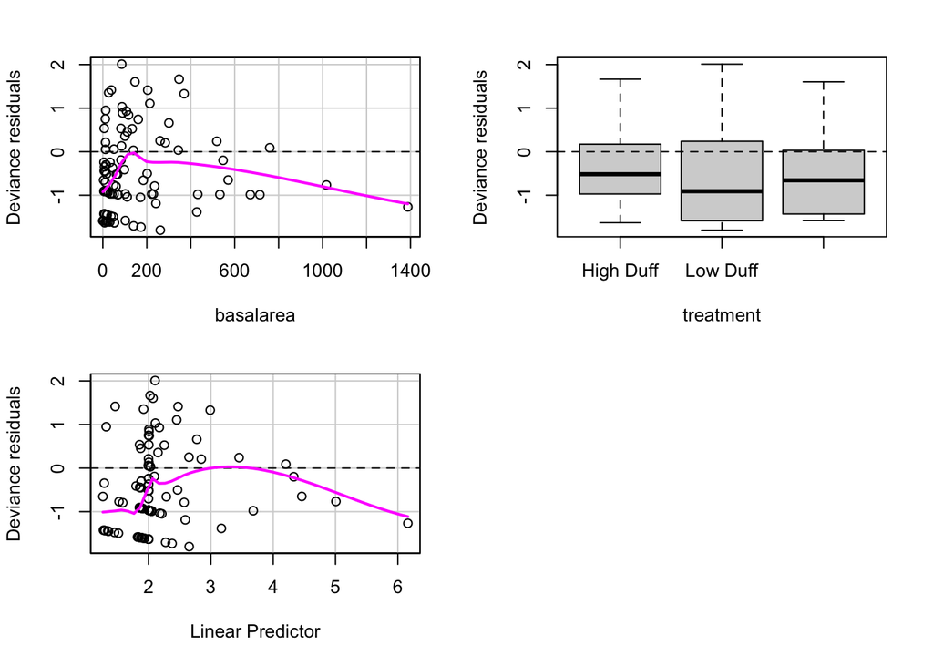

```
##           Test stat Pr(>|Test stat|)
## basalarea    8.8463         0.002937 **
## treatment
## ---
## Signif. codes:  0 '***' 0.001 '**' 0.01 '*' 0.05 '.' 0.1 ' ' 1
```

```r
residualPlots(fill1.nb, type="deviance")
```

```r
influence.measures(fill1.nb)
```

```
## Influence measures of
##   glm.nb(formula = culm ~ basalarea + treatment + basalarea * treatment,      data = fill, init.theta = 0.4727266654, link = log) :
##
##       dfb.1_  dfb.bslr  dfb.trLD  dfb.tD.P  dfb.b.LD  dfb.bD.P    dffit cov.r
## 1   1.20e-02 -6.89e-03 -9.69e-03 -8.02e-03  6.05e-03  4.27e-03  0.01200 1.127
## 2   1.01e-01  8.49e-03 -8.14e-02 -6.74e-02 -7.45e-03 -5.26e-03  0.13333 1.073
## 3  -1.14e-01  6.40e-02  9.19e-02  7.61e-02 -5.62e-02 -3.97e-02 -0.11382 1.109
## 4   2.36e-02 -7.78e-03 -1.91e-02 -1.58e-02  6.83e-03  4.82e-03  0.02503 1.110
## 5   5.58e-02  3.20e-01 -4.51e-02 -3.74e-02 -2.81e-01 -1.98e-01  0.44844 0.976
## 6   9.62e-02 -3.27e-02 -7.78e-02 -6.44e-02  2.87e-02  2.03e-02  0.10144 1.093
## 7  -7.50e-02  3.60e-02  6.07e-02  5.02e-02 -3.16e-02 -2.23e-02 -0.07597 1.110
## 8  -3.71e-01  2.17e-01  3.00e-01  2.48e-01 -1.90e-01 -1.34e-01 -0.37110 0.966
## 9  -1.99e-01  9.69e-02  1.61e-01  1.33e-01 -8.51e-02 -6.01e-02 -0.20069 1.061
## 10 -9.55e-02 -7.33e-02  7.72e-02  6.39e-02  6.44e-02  4.55e-02 -0.19065 1.055
## 11 -1.64e-01  4.16e-02  1.33e-01  1.10e-01 -3.65e-02 -2.58e-02 -0.17935 1.051
```

[output cut: 188 more lines]

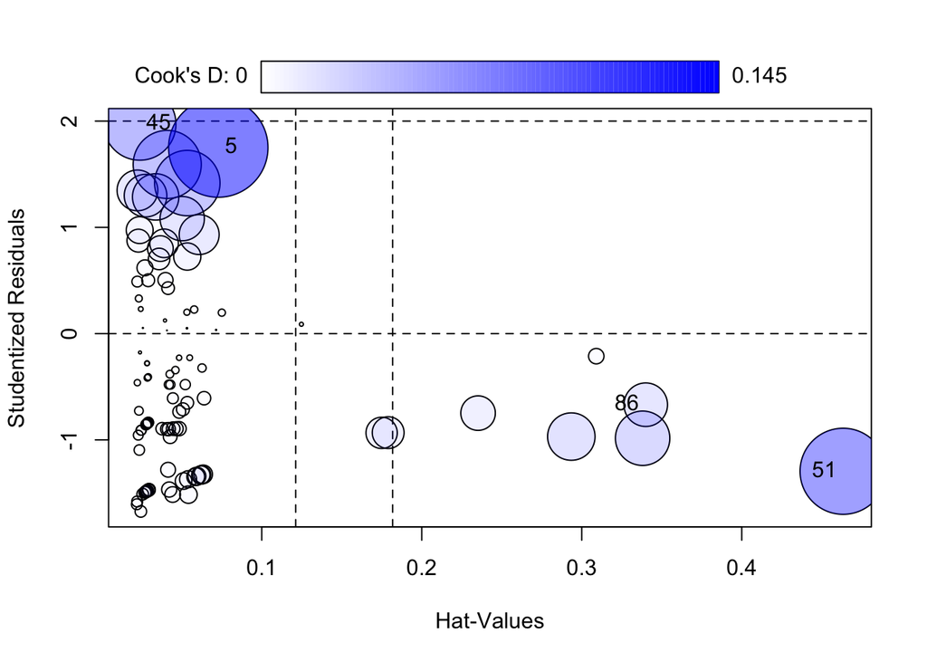

|  | StudRes | Hat | CookD |
| --- | --- | --- | --- |
| 5 | 1.7507591 | 0.07284721 | 0.14521340 |
| 45 | 1.9719789 | 0.02378786 | 0.07692456 |
| 51 | -1.2954878 | 0.46334733 | 0.10910362 |
| 86 | -0.6688643 | 0.33998104 | 0.02794775 |

```r
influencePlot(fill1.nb)
```

Dispersion statistic (note add 1 to parameters because of estimating k)

```r
nbresid <- resid(fill1.nb, type="pearson")
nbssize <- nrow(fill)
nbparams <- length(coef(fill1.nb))+1
nbdisp <- sum(nbresid^2)/(nbssize-nbparams)
nbdisp
```

```
## [1] 1.0892
```

Dispersion statistic just over 1 so much better.

## Compare to quasi-Poisson as an alternative

```r
fill.qp <- glm(culm~basalarea+treatment+basalarea*treatment, family=quasipoisson, data=fill)
fill.qp$theta
```

```r
summary(fill.qp)
```

```
##
## Call:
## glm(formula = culm ~ basalarea + treatment + basalarea * treatment,
##     family = quasipoisson, data = fill)
##
## Coefficients:
##                                           Estimate Std. Error t value Pr(>|t|)
## (Intercept)                              2.0040614  0.4001547   5.008  2.6e-06
## basalarea                                0.0000407  0.0016212   0.025   0.9800
## treatmentLow Duff                        0.2112408  0.4644455   0.455   0.6503
## treatmentLow Duff + Pinecones           -0.4384083  0.6112549  -0.717   0.4750
## basalarea:treatmentLow Duff              0.0015309  0.0016659   0.919   0.3605
## basalarea:treatmentLow Duff + Pinecones  0.0038881  0.0020622   1.885   0.0625
##
## (Intercept)                             ***
## basalarea
## treatmentLow Duff
## treatmentLow Duff + Pinecones
## basalarea:treatmentLow Duff
## basalarea:treatmentLow Duff + Pinecones .
## ---
## Signif. codes:  0 '***' 0.001 '**' 0.01 '*' 0.05 '.' 0.1 ' ' 1
##
## (Dispersion parameter for quasipoisson family taken to be 21.12124)
##
##     Null deviance: 2101.6  on 98  degrees of freedom
## Residual deviance: 1599.9  on 93  degrees of freedom
## AIC: NA
##
## Number of Fisher Scoring iterations: 6
```

```r
anova(fill.qp, test="LRT")
```

|  | Df | Deviance | Resid. Df | Resid. Dev | Pr(>Chi) |
| --- | --- | --- | --- | --- | --- |
| NULL | NA | NA | 98 | 2101.593 | NA |
| basalarea | 1 | 372.98976 | 97 | 1728.603 | 2.641978e-05 |
| treatment | 2 | 39.01603 | 95 | 1689.587 | 3.970788e-01 |
| basalarea:treatment | 2 | 89.73303 | 93 | 1599.854 | 1.195242e-01 |

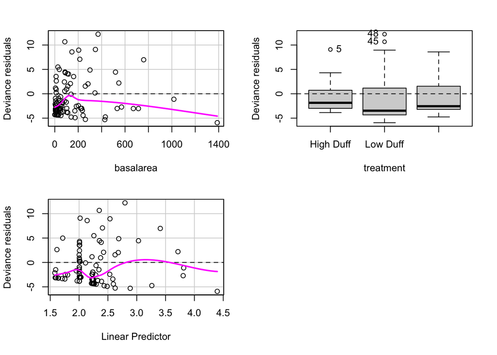

```
##           Test stat Pr(>|Test stat|)
## basalarea    247.27        < 2.2e-16 ***
## treatment
## ---
## Signif. codes:  0 '***' 0.001 '**' 0.01 '*' 0.05 '.' 0.1 ' ' 1
```

```r
residualPlots(fill.qp, type="deviance")
```

```r
influence.measures(fill.qp)
```

```
## Influence measures of
##   glm(formula = culm ~ basalarea + treatment + basalarea * treatment,      family = quasipoisson, data = fill) :
##
##       dfb.1_  dfb.bslr  dfb.trLD  dfb.tD.P  dfb.b.LD  dfb.bD.P    dffit cov.r
## 1   1.22e-02 -7.03e-03 -1.05e-02 -7.99e-03  6.84e-03  5.53e-03  0.01221 1.127
## 2   1.26e-01  9.34e-03 -1.09e-01 -8.28e-02 -9.09e-03 -7.34e-03  0.16663 1.054
## 3  -1.07e-01  6.02e-02  9.19e-02  6.98e-02 -5.86e-02 -4.74e-02 -0.10677 1.111
## 4   2.59e-02 -8.64e-03 -2.23e-02 -1.70e-02  8.41e-03  6.79e-03  0.02740 1.110
## 5   8.43e-02  4.61e-01 -7.27e-02 -5.52e-02 -4.48e-01 -3.62e-01  0.64985 0.816
## 6   1.15e-01 -3.97e-02 -9.93e-02 -7.55e-02  3.86e-02  3.12e-02  0.12144 1.086
## 7  -7.36e-02  3.56e-02  6.34e-02  4.82e-02 -3.46e-02 -2.80e-02 -0.07454 1.110
## 8  -2.28e-01  1.34e-01  1.97e-01  1.49e-01 -1.30e-01 -1.05e-01 -0.22817 1.063
## 9  -1.60e-01  7.86e-02  1.38e-01  1.05e-01 -7.65e-02 -6.18e-02 -0.16186 1.081
## 10 -7.78e-02 -5.78e-02  6.70e-02  5.09e-02  5.63e-02  4.55e-02 -0.15346 1.075
## 11 -1.33e-01  3.43e-02  1.14e-01  8.68e-02 -3.34e-02 -2.70e-02 -0.14477 1.071
```

[output cut: 188 more lines]

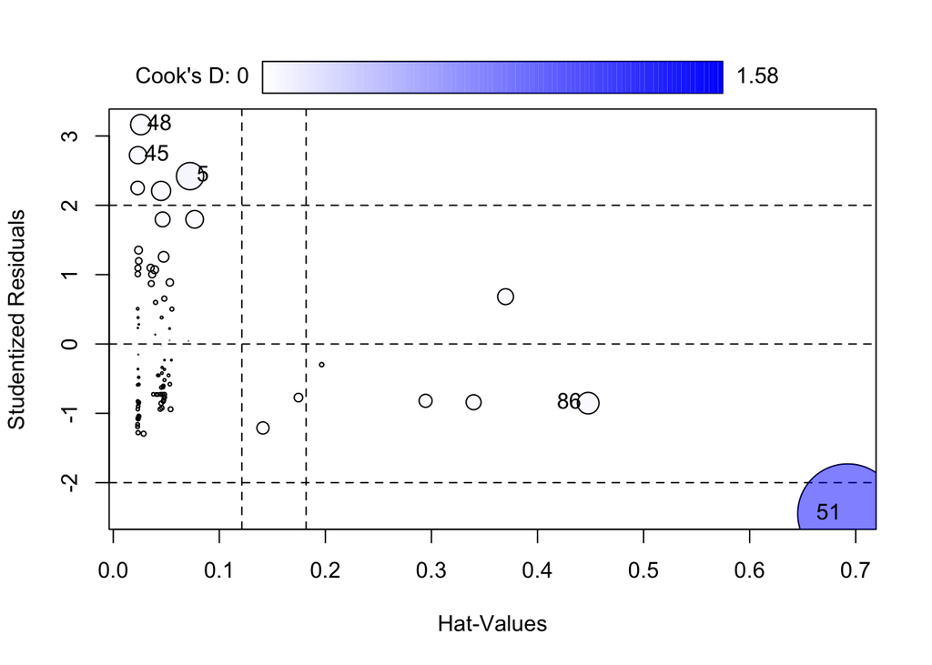

|  | StudRes | Hat | CookD |
| --- | --- | --- | --- |
| 5 | 2.4208948 | 0.07237805 | 0.11735666 |
| 45 | 2.7235202 | 0.02327481 | 0.04684940 |
| 48 | 3.1637903 | 0.02596443 | 0.06572549 |
| 51 | -2.4490785 | 0.69239565 | 1.58254735 |
| 86 | -0.8533468 | 0.44774786 | 0.07394718 |

```r
influencePlot(fill.qp)
```

## Compare with two additive zinb models

Check predicted number of zeros from -ve binomial first observed number (ignoring treatments)

```r
zerobs <- fill$culm == 0
propzerobs <- sum(zerobs)/nrow(fill)
propzerobs
```

```
## [1] 0.2222222
```

Second, predicted number from -ve binomial

```r
munb <- exp(predict(fill2.nb))
theta <- fill2.nb$theta
znb <- dnbinom(0, mu=munb, size=theta)
mean(znb)
```

```
## [1] 0.2588404
```

### ZIP1

```r
fill1.zip <- zeroinfl(culm~basalarea+treatment|1, data=fill, dist="negbin")
summary(fill1.zip)
```

```
##
## Call:
## zeroinfl(formula = culm ~ basalarea + treatment | 1, data = fill, dist = "negbin")
##
## Pearson residuals:
##     Min      1Q  Median      3Q     Max
## -0.6648 -0.6423 -0.4644  0.3078  4.2150
##
## Count model coefficients (negbin with log link):
##                                 Estimate Std. Error z value Pr(>|z|)
## (Intercept)                    1.6242903  0.3051704   5.323 1.02e-07 ***
## basalarea                      0.0030790  0.0009237   3.333 0.000858 ***
## treatmentLow Duff              0.2197260  0.3710467   0.592 0.553731
## treatmentLow Duff + Pinecones  0.0271667  0.4263111   0.064 0.949189
## Log(theta)                    -0.7847601  0.1513711  -5.184 2.17e-07 ***
##
## Zero-inflation model coefficients (binomial with logit link):
##             Estimate Std. Error z value Pr(>|z|)
## (Intercept)   -10.98      52.44  -0.209    0.834
## ---
## Signif. codes:  0 '***' 0.001 '**' 0.01 '*' 0.05 '.' 0.1 ' ' 1
##
## Theta = 0.4562
## Number of iterations in BFGS optimization: 27
## Log-likelihood: -308.5 on 6 Df
```

```r
AIC(fill1.zip)
```

```
## [1] 629.0882
```

### ZIP2

```r
fill2.zip <- zeroinfl(culm~basalarea+treatment|basalarea+treatment, data=fill, dist="negbin")
summary(fill2.zip)
```

```
##
## Call:
## zeroinfl(formula = culm ~ basalarea + treatment | basalarea + treatment,
##     data = fill, dist = "negbin")
##
## Pearson residuals:
##     Min      1Q  Median      3Q     Max
## -0.7411 -0.6064 -0.4406  0.2951  3.8527
##
## Count model coefficients (negbin with log link):
##                                 Estimate Std. Error z value Pr(>|z|)
## (Intercept)                    1.6978556  0.2759187   6.153 7.58e-10 ***
## basalarea                      0.0023901  0.0008011   2.984  0.00285 **
## treatmentLow Duff              0.3855133  0.3504975   1.100  0.27137
## treatmentLow Duff + Pinecones  0.3418503  0.4221186   0.810  0.41803
## Log(theta)                    -0.5618103  0.1732452  -3.243  0.00118 **
##
## Zero-inflation model coefficients (binomial with logit link):
##                               Estimate Std. Error z value Pr(>|z|)
## (Intercept)                   -9.79239   73.51255  -0.133    0.894
## basalarea                     -0.03272    0.02467  -1.326    0.185
## treatmentLow Duff              8.99101   73.51432   0.122    0.903
## treatmentLow Duff + Pinecones 10.23282   73.51358   0.139    0.889
## ---
## Signif. codes:  0 '***' 0.001 '**' 0.01 '*' 0.05 '.' 0.1 ' ' 1
##
## Theta = 0.5702
## Number of iterations in BFGS optimization: 39
## Log-likelihood: -305.1 on 9 Df
```

```r
AIC(fill2.zip)
```

```
## [1] 628.2315
```

```r
lrtest(fill1.zip, fill2.zip)
```

|  | #Df | LogLik | Df | Chisq | Pr(>Chisq) |
| --- | --- | --- | --- | --- | --- |
| 1 | 6 | -308.5441 | NA | NA | NA |
| 2 | 9 | -305.1157 | 3 | 6.856697 | 0.07660835 |

## Compare with linear model

```r
fill.lm <- lm(culm~basalarea+treatment+basalarea*treatment, data=fill)
summary(fill.lm)
```

```
##
## Call:
## lm(formula = culm ~ basalarea + treatment + basalarea * treatment,
##     data = fill)
##
## Residuals:
##     Min      1Q  Median      3Q     Max
## -29.845  -7.205  -4.438   2.682  64.961
##
## Coefficients:
##                                           Estimate Std. Error t value Pr(>|t|)
## (Intercept)                              7.4189045  3.6380246   2.039   0.0443
## basalarea                                0.0003059  0.0148651   0.021   0.9836
## treatmentLow Duff                       -0.5594368  4.5020291  -0.124   0.9014
## treatmentLow Duff + Pinecones           -5.2046325  5.3840301  -0.967   0.3362
## basalarea:treatmentLow Duff              0.0407534  0.0170275   2.393   0.0187
## basalarea:treatmentLow Duff + Pinecones  0.0626570  0.0241614   2.593   0.0110
##
## (Intercept)                             *
## basalarea
## treatmentLow Duff
## treatmentLow Duff + Pinecones
## basalarea:treatmentLow Duff             *
## basalarea:treatmentLow Duff + Pinecones *
## ---
## Signif. codes:  0 '***' 0.001 '**' 0.01 '*' 0.05 '.' 0.1 ' ' 1
##
## Residual standard error: 15.31 on 93 degrees of freedom
## Multiple R-squared:  0.292,  Adjusted R-squared:  0.2539
## F-statistic: 7.669 on 5 and 93 DF,  p-value: 4.502e-06
```

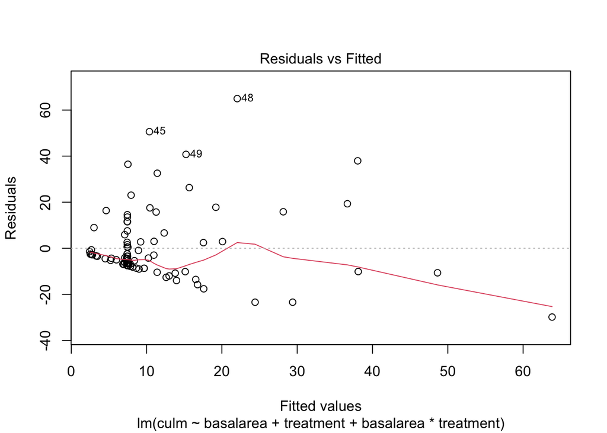

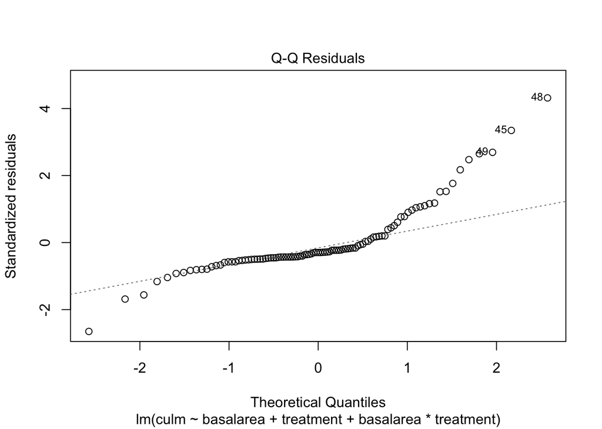

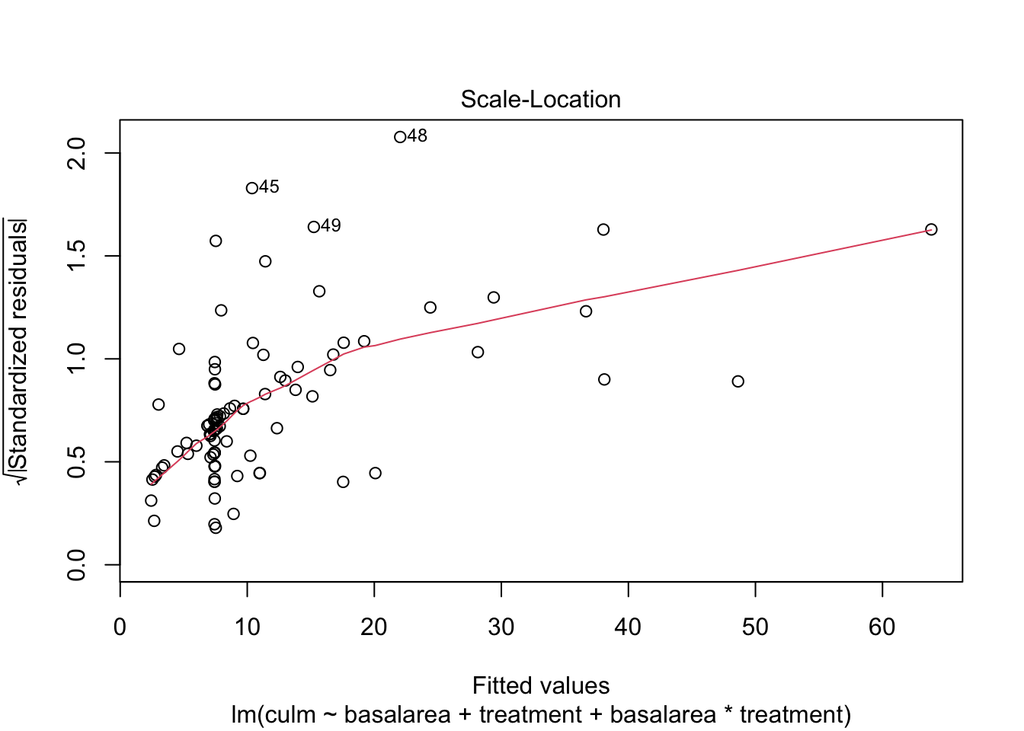

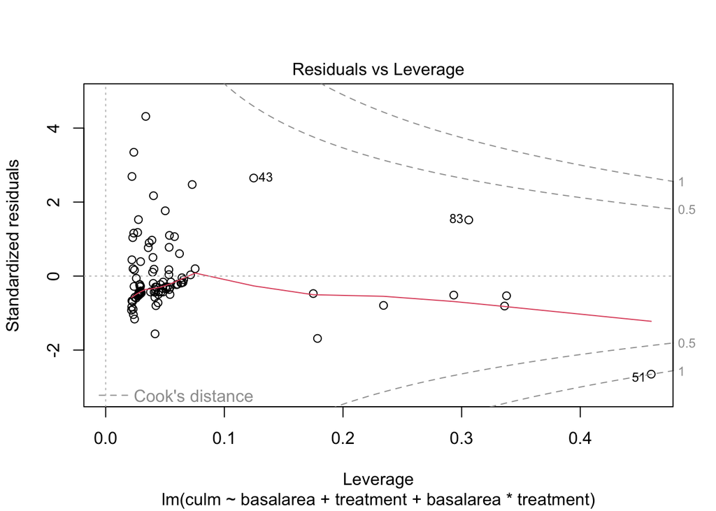

```r
plot(fill.lm)
```

```r
AIC(fill.lm)
```

```
## [1] 829.0305
```

### Try linear with sqrt transform

```r
fill.lm <- lm(sqrt(culm)~basalarea+treatment+basalarea*treatment, data=fill)
summary(fill.lm)
```

```
##
## Call:
## lm(formula = sqrt(culm) ~ basalarea + treatment + basalarea *
##     treatment, data = fill)
##
## Residuals:
##     Min      1Q  Median      3Q     Max
## -3.0962 -1.2761 -0.7173  1.1725  5.7084
##
## Coefficients:
##                                           Estimate Std. Error t value Pr(>|t|)
## (Intercept)                              2.3126014  0.4828446   4.790  6.3e-06
## basalarea                               -0.0005668  0.0019729  -0.287  0.77452
## treatmentLow Duff                       -0.6210459  0.5975168  -1.039  0.30132
## treatmentLow Duff + Pinecones           -1.3296171  0.7145774  -1.861  0.06595
## basalarea:treatmentLow Duff              0.0057803  0.0022599   2.558  0.01215
## basalarea:treatmentLow Duff + Pinecones  0.0101563  0.0032067   3.167  0.00208
##
## (Intercept)                             ***
## basalarea
## treatmentLow Duff
## treatmentLow Duff + Pinecones           .
## basalarea:treatmentLow Duff             *
## basalarea:treatmentLow Duff + Pinecones **
## ---
## Signif. codes:  0 '***' 0.001 '**' 0.01 '*' 0.05 '.' 0.1 ' ' 1
##
## Residual standard error: 2.032 on 93 degrees of freedom
## Multiple R-squared:  0.2872, Adjusted R-squared:  0.2489
## F-statistic: 7.495 on 5 and 93 DF,  p-value: 5.999e-06
```

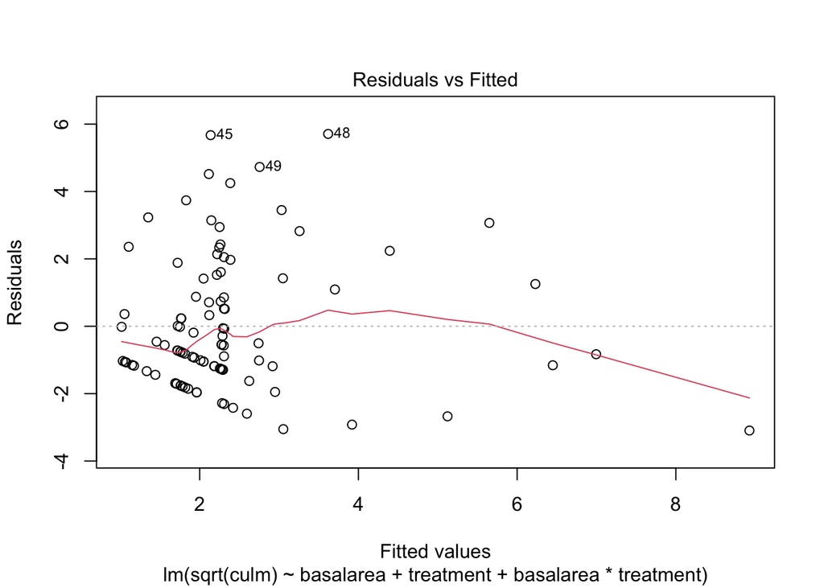

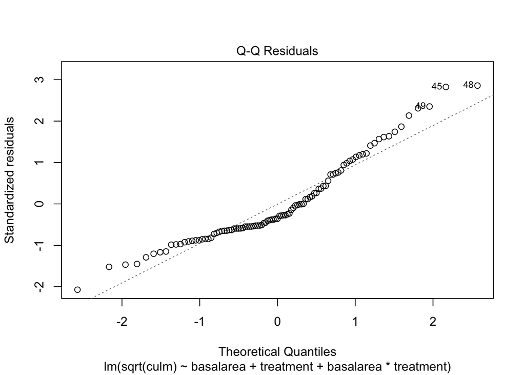

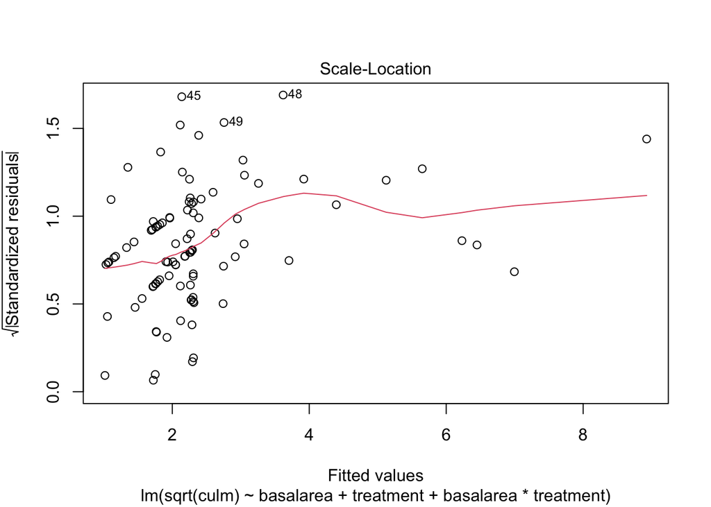

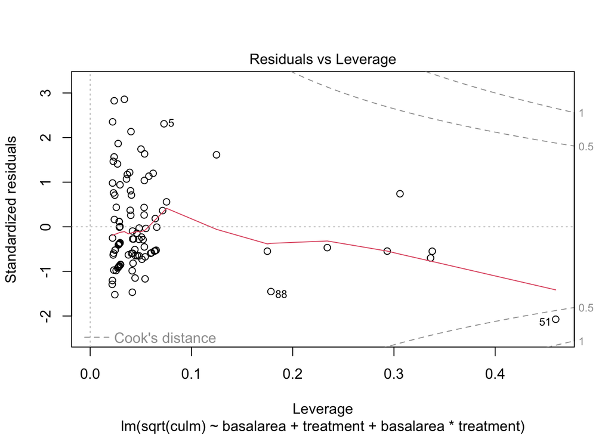

```r
plot(fill.lm)
```

```r
AIC(fill.lm)
```

```
## [1] 429.1693
```